# Test-Retest Reliability of Core Lexicon Analysis

Authors

Affiliations

Sarah Grace Dalton

University of Georgia, Department of Communication Sciences and Special Education

Robert Cavanaugh

MGH Institute of Health Professions, School of Health and Rehabilitation Sciences

Brielle C. Stark

Indiana University Bloomington, Department of Speech, Language, and Hearing Sciences

Published

February 26, 2026

### Load packages and setup file reading

```r
library(tidyverse)
library(here)
library(lme4)
library(readxl)
library(boot)
library(flextable)
library(easystats)
library(officer)

source("gtheory-icc.R")
set.seed(42)

raw_data <- read_csv(here::here("data", "corelex-deid-data.csv"))

bootstrap_n = 1000
```

### Data Cleaning

```r
all_data = raw_data |>
  select(-difference) |>
  pivot_longer(cols = starts_with("t"),
               names_to = "time",
               values_to = "score") |>
  rename(stimuli = sheet_name) |>
  mutate(across(where(is.character), as.factor),
         participant = as.factor(paste0("p", str_extract(participant, "^[^.]*")))) |>
  mutate(max_score = case_when(
    stimuli == "Cat" ~ 35,
    stimuli == "Cinderella" ~ 95,
    stimuli == "Sandwich" ~ 25,
    stimuli == "Umbrella" ~ 36,
    stimuli == "Window" ~ 24,
    TRUE ~ NA
  )) |>
  mutate(percent_acc = score/max_score)

knitr::kable(head(all_data))
```

| stimuli | participant | dx | time | score | max_score | percent_acc |
| --- | --- | --- | --- | --- | --- | --- |
| Cat | pP49 | pwa | t1 | 25 | 35 | 0.7142857 |
| Cat | pP49 | pwa | t2 | 30 | 35 | 0.8571429 |
| Cat | pP101 | pwa | t1 | 25 | 35 | 0.7142857 |
| Cat | pP101 | pwa | t2 | 24 | 35 | 0.6857143 |
| Cat | pP65 | pwa | t1 | 0 | 35 | 0.0000000 |
| Cat | pP65 | pwa | t2 | 5 | 35 | 0.1428571 |

### Visualize test-retest

- did not use thsi figure; see figure at end of doc with 95% PI

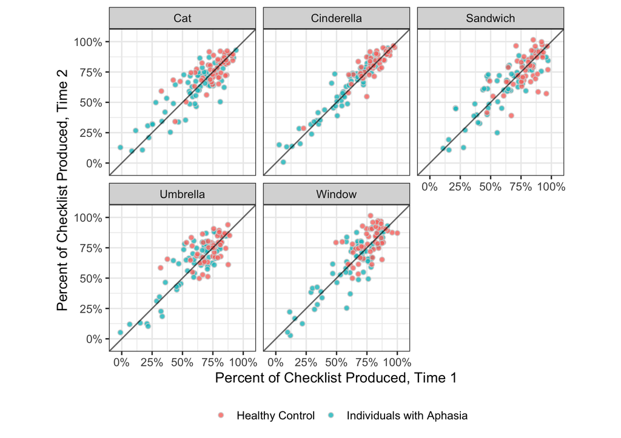

```r
all_wide = all_data |> select(-score) |>
  pivot_wider(names_from = time, values_from = percent_acc)

p1 = all_wide |>
  mutate(dx = ifelse(dx == "control", "Healthy Control", "Individuals with Aphasia")) |>
  ggplot(aes(x = t1, y = t2, fill = dx)) +
  #geom_point() +
  geom_jitter(alpha = 0.8, size = 2, shape = 21, color = "lightgrey", width = .015, height = 0.015) +
  geom_abline(alpha = 0.6) +
  facet_wrap(~stimuli, ncol = 3) +
  scale_y_continuous(limits = c(-0.05, 1.05), labels = scales::label_percent(), breaks = seq(0, 1, 0.25)) +
  scale_x_continuous(limits = c(-0.05, 1.05), labels = scales::label_percent(), breaks = seq(0, 1, 0.25)) +
  theme_bw(base_size = 14) +
  theme(legend.position = "bottom", aspect.ratio = 1) +
  labs(fill = "", x = "Percent of Checklist Produced, Time 1", y = "Percent of Checklist Produced, Time 2") +
  coord_fixed()

ggsave(plot = p1, here::here("output" , "figure 1.png"), height = 7, width = 9)

p1
```

### Estimating reliability under a G-theory framework; Revision: Binomial Model

In our revision, we adjusted the model to take the proportion of core lex words produced rather than just the count. We need to check for overdispersion. This was run for each combination of the models. Dispersion ratios farther away from 1 (p<0.05) indicate over or underdispersion, the former being more problematic. In this case, the data are equidispersed.

```r
overdispersion <- all_data |>
  group_nest(stimuli, dx) |>
  mutate(
    od = map(data, ~{
      m <- glmer(cbind(score, max_score - score) ~ 1 + (1|participant) + (1|time),
                 data = .x, family = binomial())
      performance::check_overdispersion(m)
    }),
    dispersion_ratio = map_dbl(od, ~.x$dispersion_ratio),
    p_value = map_dbl(od, ~.x$p_value)
  ) |>
  select(stimuli, dx, dispersion_ratio, p_value)

knitr::kable(overdispersion)
```

| stimuli | dx | dispersion_ratio | p_value |
| --- | --- | --- | --- |
| Cat | control | 1.1002694 | 0.496 |
| Cat | pwa | 1.0119786 | 0.984 |
| Cinderella | control | 1.0714470 | 0.728 |
| Cinderella | pwa | 0.9848613 | 0.904 |
| Sandwich | control | 1.0613141 | 0.640 |
| Sandwich | pwa | 1.0137899 | 0.912 |
| Umbrella | control | 1.0978026 | 0.464 |
| Umbrella | pwa | 1.0030880 | 1.000 |
| Window | control | 0.9782793 | 0.984 |
| Window | pwa | 1.0244964 | 0.912 |

```r
# Run ICC analysis on all stimuli / dx
icc_A1 <- all_data |>
  group_nest(stimuli, dx) |>
  mutate(
    icc_results = map(data,
                      ~calc_icc_formula_binomial(cbind(score, max_score - score) ~ 1 + (1|participant) + (1|time),
                      "participant", .x, R = bootstrap_n))
  )

# Extract ICC results table
icc_table <- icc_A1 |>
  mutate(icc_data = map(icc_results, "icc_results")) |>
  select(stimuli, dx, icc_data) |>
  unnest(icc_data)

# Extract variance components table
variance_table <- icc_A1 |>
  mutate(var_data = map(icc_results, "variance_components")) |>
  select(stimuli, dx, var_data) |>
  unnest(var_data)

manuscript_table = icc_table |>
  select(Stimuli = stimuli, Group = dx, Dependability = icc, `95% CI` = `ci_95`) |>
  flextable() |>
  set_table_properties(align = "left") |>   # Make sure table is left-aligned
  flextable::set_caption(apa_caption("Table X. Dependability Coefficients by Stimuli and Group"), align_with_table = TRUE,
                         word_stylename = "Normal",
                         fp_p = fp_par(text.align = "left")) |>
  flextable::autofit(add_w = 0, add_h = 1) |>
  flextable::add_footer_lines(values = "Note: Dependability coefficients are analogous to intraclass correlations for agreement") |>
  theme_apa2()

# To save it as a word document:
doc <- officer::read_docx()
# add the table to the document
doc <- body_add_flextable(doc, value = manuscript_table)
# filename within the path we want
print(doc, target = "output/icc_by_stimuli_and_group_revision.docx")


knitr::kable(icc_table)
```

| stimuli | dx | icc | ci_lower | ci_upper | ci_95 | formula | bootstrap_success_rate |
| --- | --- | --- | --- | --- | --- | --- | --- |
| Cat | control | 0.64 | 0.46 | 0.74 | [0.46, 0.74] | σ²participant / (σ²participant + σ²time + σ²residual) | 1 |
| Cat | pwa | 0.88 | 0.81 | 0.92 | [0.81, 0.92] | σ²participant / (σ²participant + σ²time + σ²residual) | 1 |
| Cinderella | control | 0.88 | 0.79 | 0.93 | [0.79, 0.93] | σ²participant / (σ²participant + σ²time + σ²residual) | 1 |
| Cinderella | pwa | 0.96 | 0.93 | 0.98 | [0.93, 0.98] | σ²participant / (σ²participant + σ²time + σ²residual) | 1 |
| Sandwich | control | 0.59 | 0.39 | 0.69 | [0.39, 0.69] | σ²participant / (σ²participant + σ²time + σ²residual) | 1 |
| Sandwich | pwa | 0.85 | 0.77 | 0.89 | [0.77, 0.89] | σ²participant / (σ²participant + σ²time + σ²residual) | 1 |
| Umbrella | control | 0.56 | 0.39 | 0.65 | [0.39, 0.65] | σ²participant / (σ²participant + σ²time + σ²residual) | 1 |
| Umbrella | pwa | 0.88 | 0.78 | 0.92 | [0.78, 0.92] | σ²participant / (σ²participant + σ²time + σ²residual) | 1 |
| Window | control | 0.49 | 0.35 | 0.57 | [0.35, 0.57] | σ²participant / (σ²participant + σ²time + σ²residual) | 1 |
| Window | pwa | 0.83 | 0.72 | 0.88 | [0.72, 0.88] | σ²participant / (σ²participant + σ²time + σ²residual) | 1 |

They are very similar. Minor differences in the confidence intervals do not impact conclusions.

### Consistency ICCs

Generalizability coefficients or Consistency ICCs for situations where absolute agreement is not necessary, as recommended by tenHove 2024.

```r
# Run ICC analysis on all stimuli / dx
icc_C1 <- all_data |>
  group_nest(stimuli, dx) |>
  mutate(
    icc_results = map(data, ~calc_icc_formula_binomial(cbind(score, max_score - score) ~ 1 + time + (1|participant), "participant", .x, R = bootstrap_n))
  )

# Extract ICC results table
icc_table_c <- icc_C1 |>
  mutate(icc_data = map(icc_results, "icc_results")) |>
  select(stimuli, dx, icc_data) |>
  unnest(icc_data)

# Extract variance components table
variance_table_c <- icc_C1 |>
  mutate(var_data = map(icc_results, "variance_components")) |>
  select(stimuli, dx, var_data) |>
  unnest(var_data)

practice_effects <- icc_C1 |>
     mutate(params = map(icc_results, "parameters")) |>
     select(stimuli, dx, params) |>
     unnest(params) |> filter(Effects == "fixed", Parameter == "timet2")

manuscript_table2 = icc_table_c |>
    select(Stimuli = stimuli, Group = dx, 'Generalizability' = icc, `95% CI` = `ci_95`) |>
  flextable() |>
  set_table_properties(align = "left") |>   # Make sure table is left-aligned
  flextable::set_caption(apa_caption("Table X. Generalizability Coefficients by Stimuli and Group"), align_with_table = TRUE,
                         word_stylename = "Normal",
                         fp_p = fp_par(text.align = "left")) |>
  flextable::autofit(add_w = 0, add_h = 1) |>
  flextable::add_footer_lines(values = "Note: Generalizability coefficients are analogous to intraclass correlations for consistency") |>
  theme_apa2()

# To save it as a word document:
doc <- officer::read_docx()
# add the table to the document
doc <- body_add_flextable(doc, value = manuscript_table2)
# filename within the path we want
print(doc, target = "output/icc_by_stimuli_and_group_consistency_revision.docx")


knitr::kable(icc_table_c |> select(-ci_lower, -ci_upper))
```

| stimuli | dx | icc | ci_95 | formula | bootstrap_success_rate |
| --- | --- | --- | --- | --- | --- |
| Cat | control | 0.65 | [0.47, 0.74] | σ²participant / (σ²participant + σ²residual) | 1 |
| Cat | pwa | 0.88 | [0.81, 0.92] | σ²participant / (σ²participant + σ²residual) | 1 |
| Cinderella | control | 0.89 | [0.8, 0.93] | σ²participant / (σ²participant + σ²residual) | 1 |
| Cinderella | pwa | 0.97 | [0.94, 0.98] | σ²participant / (σ²participant + σ²residual) | 1 |
| Sandwich | control | 0.60 | [0.42, 0.69] | σ²participant / (σ²participant + σ²residual) | 1 |
| Sandwich | pwa | 0.85 | [0.77, 0.89] | σ²participant / (σ²participant + σ²residual) | 1 |
| Umbrella | control | 0.56 | [0.4, 0.66] | σ²participant / (σ²participant + σ²residual) | 1 |
| Umbrella | pwa | 0.88 | [0.78, 0.92] | σ²participant / (σ²participant + σ²residual) | 1 |
| Window | control | 0.49 | [0.34, 0.58] | σ²participant / (σ²participant + σ²residual) | 1 |
| Window | pwa | 0.83 | [0.71, 0.89] | σ²participant / (σ²participant + σ²residual) | 1 |

- here’s a table of both sets of coefficients:

```r
icc_all = icc_table |>
  select(stimuli, dx, icc_a1 = icc, ci_95_a1 = ci_95) |>
  left_join(
    icc_table_c |> select(stimuli, dx, icc_c1 = icc, ci_95_c1 = ci_95),
    by = join_by(stimuli, dx)
  )

manuscript_table4 = icc_all |>
  rename(Stimuli = stimuli, Group = dx) |>
  flextable() |>
  set_table_properties(align = "left") |>
  compose(
    j = "icc_a1",
    part = "header",
    #value = as_paragraph("ICC", as_sub("A,1"))
    value = as_paragraph("Dependability")
  ) |>
  compose(
    j = "ci_95_a1",
    part = "header",
    #value = as_paragraph("95% CI", as_sub("A,1"))
    value = as_paragraph("95% CI")
  ) |>
  compose(
    j = "icc_c1",
    part = "header",
    #value = as_paragraph("ICC", as_sub("C,1"))
    value = as_paragraph("Generalizability")
  ) |>
  compose(
    j = "ci_95_c1",
    part = "header",
   # value = as_paragraph("95% CI", as_sub("C,1"))
       value = as_paragraph("95% CI")

  ) |>
  flextable::set_caption(apa_caption("Table 3. Estimates of Dependability and Generalizability by stimulus for individuals with aphasia and healthy controls"),
                         align_with_table = TRUE,
                         word_stylename = "Normal",
                         fp_p = fp_par(text.align = "left")) |>
  flextable::autofit(add_w = 0, add_h = 1) |>
    flextable::add_footer_lines(values = "Note: Dependability coefficients are analogous to single-rater agreement intraclass correlation coefficients and Generalizability coefficients are analogous to single-rater consistency intraclass correlation coefficients. ") |>
  theme_apa2()

# To save it as a word document:
doc <- officer::read_docx()
# add the table to the document
doc <- body_add_flextable(doc, value = manuscript_table4)
# filename within the path we want
print(doc, target = "output/icc_by_stimuli_and_group_all-revision.docx")

manuscript_table4
```

| Stimuli | Group | Dependability | 95% CI | Generalizability | 95% CI |
| --- | --- | --- | --- | --- | --- |
| Cat | control | 0.64 | [0.46, 0.74] | 0.65 | [0.47, 0.74] |
| Cat | pwa | 0.88 | [0.81, 0.92] | 0.88 | [0.81, 0.92] |
| Cinderella | control | 0.88 | [0.79, 0.93] | 0.89 | [0.8, 0.93] |
| Cinderella | pwa | 0.96 | [0.93, 0.98] | 0.97 | [0.94, 0.98] |
| Sandwich | control | 0.59 | [0.39, 0.69] | 0.60 | [0.42, 0.69] |
| Sandwich | pwa | 0.85 | [0.77, 0.89] | 0.85 | [0.77, 0.89] |
| Umbrella | control | 0.56 | [0.39, 0.65] | 0.56 | [0.4, 0.66] |
| Umbrella | pwa | 0.88 | [0.78, 0.92] | 0.88 | [0.78, 0.92] |
| Window | control | 0.49 | [0.35, 0.57] | 0.49 | [0.34, 0.58] |
| Window | pwa | 0.83 | [0.72, 0.88] | 0.83 | [0.71, 0.89] |

Note: Dependability coefficients are analogous to single-rater agreement intraclass correlation coefficients and Generalizability coefficients are analogous to single-rater consistency intraclass correlation coefficients.

We can also get estimates of “time” to examine practice effects directly:

```r
time_table = practice_effects <- icc_C1 |>
     mutate(params = map(icc_results, "parameters")) |>
     select(stimuli, dx, params) |>
     unnest(params) |> filter(Effects == "fixed", Parameter == "timet2") |>
     format_table()

time_table_manuscript = time_table |>
  select(-Effects, -df, -z, -Group, Stimuli = stimuli) |>
  rename(Group = dx) |>
  flextable() |>
  set_table_properties(align = "left") |>   # Make sure table is left-aligned
  flextable::set_caption(apa_caption("Supplemental Table 1. Fixed effects of time for all stimuli and groups"), align_with_table = TRUE,
                         word_stylename = "Normal",
                         fp_p = fp_par(text.align = "left")) |>
  flextable::autofit(add_w = 0, add_h = 1) |>
  flextable::add_footer_lines(values = "") |>
  theme_apa2()

# To save it as a word document:
doc <- officer::read_docx()
# add the table to the document
doc <- body_add_flextable(doc, value = time_table_manuscript)
# filename within the path we want
print(doc, target = "output/supplement-time-1_revision.docx")

knitr::kable(time_table)
```

| stimuli | dx | Parameter | Coefficient | SE | 95% CI | z | df | p | Effects | Group |
| --- | --- | --- | --- | --- | --- | --- | --- | --- | --- | --- |
| Cat | control | timet2 | 0.11 | 0.08 | [-0.04, 0.27] | 1.43 | Inf | 0.154 | fixed |  |
| Cat | pwa | timet2 | 0.06 | 0.07 | [-0.07, 0.19] | 0.84 | Inf | 0.403 | fixed |  |
| Cinderella | control | timet2 | 0.10 | 0.05 | [ 0.00, 0.21] | 1.99 | Inf | 0.047 | fixed |  |
| Cinderella | pwa | timet2 | 0.12 | 0.04 | [ 0.04, 0.20] | 2.87 | Inf | 0.004 | fixed |  |
| Sandwich | control | timet2 | -0.12 | 0.10 | [-0.31, 0.07] | -1.23 | Inf | 0.220 | fixed |  |
| Sandwich | pwa | timet2 | 0.07 | 0.08 | [-0.09, 0.23] | 0.83 | Inf | 0.407 | fixed |  |
| Umbrella | control | timet2 | 0.10 | 0.08 | [-0.04, 0.25] | 1.37 | Inf | 0.170 | fixed |  |
| Umbrella | pwa | timet2 | 0.11 | 0.07 | [-0.02, 0.23] | 1.59 | Inf | 0.111 | fixed |  |
| Window | control | timet2 | 0.17 | 0.10 | [-0.03, 0.36] | 1.69 | Inf | 0.092 | fixed |  |
| Window | pwa | timet2 | -0.04 | 0.08 | [-0.20, 0.12] | -0.54 | Inf | 0.593 | fixed |  |

### Overall effects including all stimuli

Looking at reliability as if stimuli were facets. This includes estimates with and without group as a fixed effect

```r
# first we have to standardize the scores. I've done this by calculating %
# accuracy using the max possible scores. this normalizes the scores accounting
# for stimuli length.

icc_5 = calc_icc_formula_binomial(
  formula = cbind(score, max_score-score) ~ (1|participant) + (1|stimuli) + (1|stimuli:participant) + (1|time) + (1|time:participant) + (1|time:stimuli),
  icc_facet = "participant",
  R = bootstrap_n,
  data = all_data
)

icc_5_dx = calc_icc_formula_binomial(
  formula = cbind(score, max_score-score) ~ 1 + dx + (1|participant) + (1|stimuli)+ (1|stimuli:participant),
  icc_facet = "participant",
  R = bootstrap_n,
  data = all_data
)
```

```r
knitr::kable(bind_rows(icc_5$icc_results |> mutate(method = "collapsed") |> select(-ci_upper, -ci_lower),
                       icc_5_dx$icc_results |> mutate(method = "dx-removed") |> select(-ci_upper, -ci_lower)
                       ))
```

| icc | ci_95 | formula | bootstrap_success_rate | method |
| --- | --- | --- | --- | --- |
| 0.76 | [0.67, 0.82] | σ²participant / (σ²stimuli:participant + σ²time:participant + σ²participant + σ²time:stimuli + σ²stimuli + σ²time + σ²residual) | 1 | collapsed |
| 0.71 | [0.6, 0.78] | σ²participant / (σ²stimuli:participant + σ²participant + σ²stimuli + σ²residual) | 1 | dx-removed |

Then we split out pwa and control particpants:

```r
pwa = all_data |> filter(dx == "pwa")
control = all_data |> filter(dx == "control")

# Call function
icc_5_pwa <- calc_icc_formula_binomial(
  formula = cbind(score, max_score-score) ~ (1|participant) + (1|stimuli) + (1|stimuli:participant) + (1|time) + (1|time:participant) + (1|time:stimuli),
  icc_facet = "participant",
  R = bootstrap_n,
  data = pwa
)

# Call function
icc_5_control <- calc_icc_formula_binomial(
  formula = cbind(score, max_score-score) ~ (1|participant) + (1|stimuli) + (1|stimuli:participant) + (1|time) + (1|time:participant) + (1|time:stimuli),
  icc_facet = "participant",
  R = bootstrap_n,
  data = control
)
```

### Decision study

- what would be the effects of averaging 1…5 stimuli on reliability?
- we can use the models and bootstrapped iterations to derive these estimates and uncertainty values

```r
# Get decision study results instantly (no refitting!)
decision_study_pwa <- calc_decision_study_from_bootstrap(icc_5_pwa) |> mutate(group = "pwa")
decision_study_pwa
```

```
# A tibble: 5 × 6
  n_stimuli phi_coefficient ci_lower ci_upper ci_95        group
      <int>           <dbl>    <dbl>    <dbl> <chr>        <chr>
1         1            0.89     0.82     0.92 [0.82, 0.92] pwa
2         2            0.94     0.89     0.96 [0.89, 0.96] pwa
3         3            0.95     0.92     0.97 [0.92, 0.97] pwa
4         4            0.96     0.93     0.98 [0.93, 0.98] pwa
5         5            0.97     0.94     0.98 [0.94, 0.98] pwa
```

```r
# Get decision study results instantly (no refitting!)
decision_study_control <- calc_decision_study_from_bootstrap(icc_5_control) |> mutate(group = "control")
decision_study_control
```

```
# A tibble: 5 × 6
  n_stimuli phi_coefficient ci_lower ci_upper ci_95        group
      <int>           <dbl>    <dbl>    <dbl> <chr>        <chr>
1         1            0.51     0.36     0.62 [0.36, 0.62] control
2         2            0.67     0.52     0.76 [0.52, 0.76] control
3         3            0.74     0.6      0.82 [0.6, 0.82]  control
4         4            0.78     0.65     0.86 [0.65, 0.86] control
5         5            0.81     0.68     0.88 [0.68, 0.88] control
```

```r
ds = bind_rows(
  decision_study_pwa,
  decision_study_control
)

knitr::kable(ds)
```

| n_stimuli | phi_coefficient | ci_lower | ci_upper | ci_95 | group |
| --- | --- | --- | --- | --- | --- |
| 1 | 0.89 | 0.82 | 0.92 | [0.82, 0.92] | pwa |
| 2 | 0.94 | 0.89 | 0.96 | [0.89, 0.96] | pwa |
| 3 | 0.95 | 0.92 | 0.97 | [0.92, 0.97] | pwa |
| 4 | 0.96 | 0.93 | 0.98 | [0.93, 0.98] | pwa |
| 5 | 0.97 | 0.94 | 0.98 | [0.94, 0.98] | pwa |
| 1 | 0.51 | 0.36 | 0.62 | [0.36, 0.62] | control |
| 2 | 0.67 | 0.52 | 0.76 | [0.52, 0.76] | control |
| 3 | 0.74 | 0.60 | 0.82 | [0.6, 0.82] | control |
| 4 | 0.78 | 0.65 | 0.86 | [0.65, 0.86] | control |
| 5 | 0.81 | 0.68 | 0.88 | [0.68, 0.88] | control |

- and plot the results:

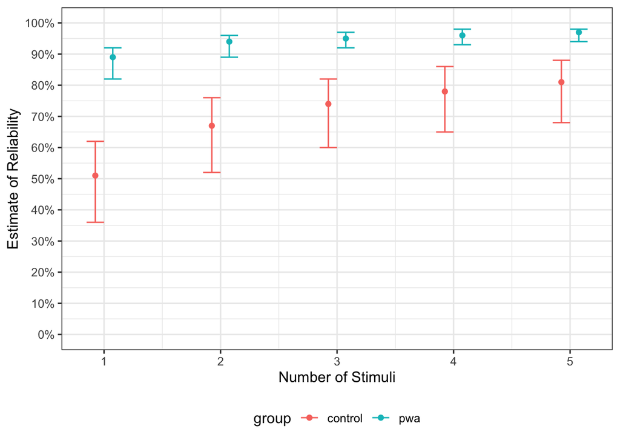

```r
ds_plot = ds |>
  ggplot(aes(x = n_stimuli, y = phi_coefficient, color = group)) +
  geom_point( position = position_dodge(0.3)) +
  geom_errorbar(aes(ymin=ci_lower, ymax = ci_upper), width = 0.3, position = position_dodge(0.3)) +
  theme_bw(base_size = 12) +
  scale_y_continuous(labels = scales::label_percent(), breaks = seq(0, 1, 0.1), limits = c(0,1)) +
  theme(legend.position = "bottom") +
  labs(y = "Estimate of Reliability", x = "Number of Stimuli")

ggsave(plot = ds_plot, filename = here::here("output", "decision-study-revision.png"))
ds_plot
```

### MDC

Calculating MDC for each stimuli. MDC 95 can also be derived from the initial models; calcuating the SEM

- this returns estimates of MDC in the number of items for 5-item ranges throughout the range of possible options

```r
mdc <- all_data |>
  group_by(stimuli, dx) |>
  summarise(
    mdc_logit = calc_mdc_formula_binomial(
      formula = cbind(score, max_score - score) ~ (1|participant) + (1|time),
      icc_facet = "participant",
      exclude_from_error = NULL,
      data = cur_data()
    ),
    .groups = "drop"
  ) |>
  left_join(all_data |> distinct(stimuli, max_score), by = "stimuli")

# Step 2: Create MDC lookup tables by baseline
mdc_tables <- calc_mdc_by_baseline(mdc)
readr::write_csv(mdc_tables, here::here("output", "Supplement 2 - MDC by stimuli.csv"))

# Create plot data
plot_data <- mdc |>
  mutate(
    plot_data = map(mdc_logit, function(mdc_log) {
      tibble(baseline = seq(0.05, 0.95, by = 0.01)) |>
        mutate(
          baseline_logit = qlogis(baseline),
          lower_pct = plogis(baseline_logit - mdc_log),
          upper_pct = plogis(baseline_logit + mdc_log)
        )
    })
  ) |>
  select(stimuli, dx, plot_data) |>
  unnest(plot_data)

head(mdc_tables)
```

```
# A tibble: 6 × 7
  stimuli dx      max_score stratum score_range `mdc (items)` mdc_percentage
  <fct>   <fct>       <dbl>   <int> <chr>               <dbl>          <dbl>
1 Cat     control        35       1 0-5                     5          0.139
2 Cat     control        35       2 6-10                    7          0.200
3 Cat     control        35       3 11-15                   8          0.210
4 Cat     control        35       4 16-20                   8          0.204
5 Cat     control        35       5 21-25                   7          0.179
6 Cat     control        35       6 26-30                   5          0.129
```

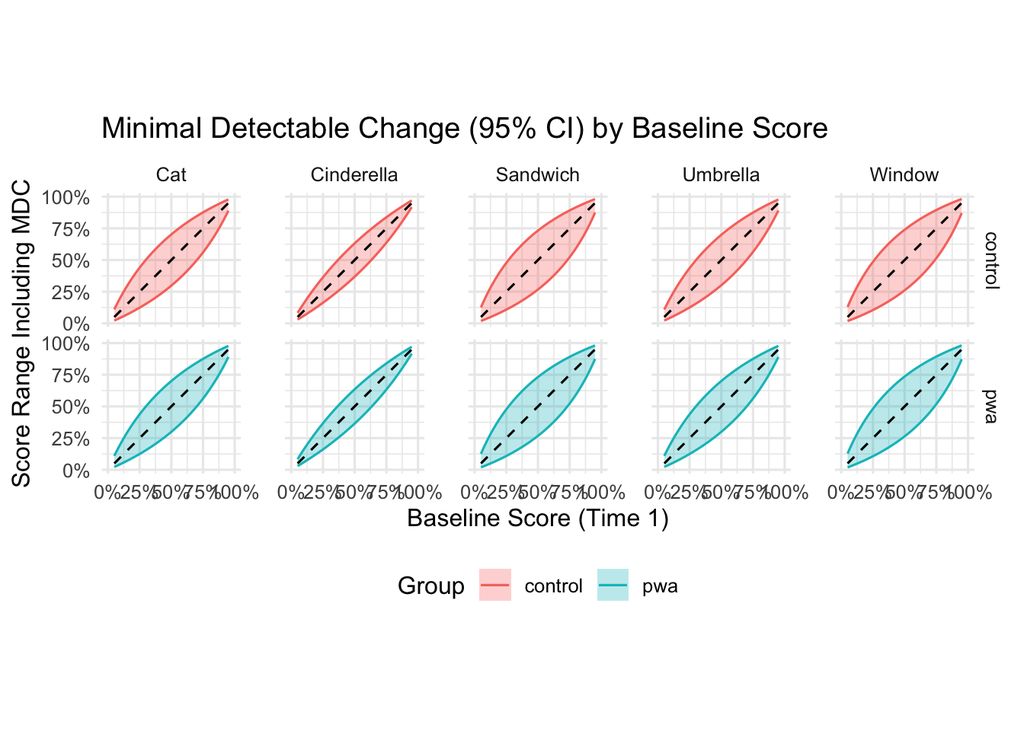

```r
# Create plot
p = ggplot(plot_data, aes(x = baseline)) +
  geom_ribbon(aes(ymin = lower_pct, ymax = upper_pct, fill = dx),
              alpha = 0.3) +
  geom_line(aes(y = baseline), linetype = "dashed", color = "black") +
  geom_line(aes(y = lower_pct, color = dx)) +
  geom_line(aes(y = upper_pct, color = dx)) +
  facet_grid(dx~stimuli) +
  scale_x_continuous(labels = scales::percent, breaks = seq(0, 1, 0.25), limits = c(0, 1)) +
  scale_y_continuous(labels = scales::percent, breaks = seq(0, 1, 0.25)) +
  coord_fixed() +
  theme_minimal(base_size = 12) +
  theme(legend.position = "bottom", panel.spacing.x = unit(1.5, "lines")) +
  labs(
    x = "Baseline Score (Time 1)",
    y = "Score Range Including MDC",
    title = "Minimal Detectable Change (95% CI) by Baseline Score",
    fill = "Group",
    color = "Group"
  )

ggsave(plot = p, filename = "MDC-by-stimuli-baseline.png")
p
```

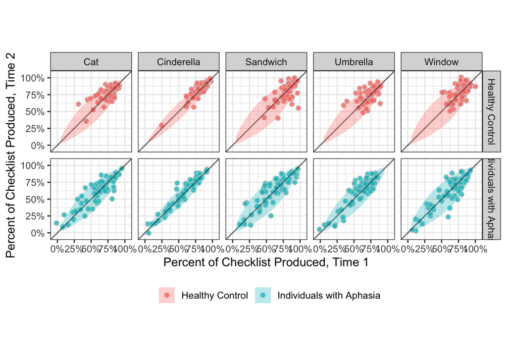

```r
p = all_wide |>
  mutate(dx = ifelse(dx == "control", "Healthy Control", "Individuals with Aphasia")) |>
  ggplot(aes(x = t1, y = t2, fill = dx)) +
  #geom_point() +
  geom_jitter(alpha = 0.8, size = 2, shape = 21, color = "lightgrey", width = .015, height = 0.015) +
  geom_abline(alpha = 0.6) +
  geom_ribbon(inherit.aes = FALSE,
              data = plot_data |> rename(t1 = baseline) |> mutate(dx = ifelse(dx == "control", "Healthy Control", "Individuals with Aphasia")),
              aes(x = t1, ymin = lower_pct, ymax = upper_pct, fill = dx),
              alpha = 0.3) +
  facet_grid(dx~stimuli) +
  scale_y_continuous(limits = c(-0.05, 1.05), labels = scales::label_percent(), breaks = seq(0, 1, 0.25)) +
  scale_x_continuous(limits = c(-0.05, 1.05), labels = scales::label_percent(), breaks = seq(0, 1, 0.25)) +
  theme_bw(base_size = 12) +
  theme(legend.position = "bottom", aspect.ratio = 1) +
  labs(fill = "", x = "Percent of Checklist Produced, Time 1", y = "Percent of Checklist Produced, Time 2") +
  coord_fixed()

ggsave(plot = p, filename = here::here("output", "figure 1 - revision.png"), width = 12, height = 10)

p
```

```r
sems = all_data |>
  group_by(stimuli, dx) |>
  summarise(
    sem_logit = calc_sem(
      formula = cbind(score, max_score - score) ~ (1|participant) + (1|time),
      icc_facet = "participant",
      exclude_from_error = NULL,
      data = cur_data()
    ),
    .groups = "drop"
  )

knitr::kable(sems)
```

| stimuli | dx | sem_logit |
| --- | --- | --- |
| Cat | control | 0.3092480 |
| Cat | pwa | 0.3065880 |
| Cinderella | control | 0.1945994 |
| Cinderella | pwa | 0.2001493 |
| Sandwich | control | 0.3636117 |
| Sandwich | pwa | 0.3627599 |
| Umbrella | control | 0.3040321 |
| Umbrella | pwa | 0.3065715 |
| Window | control | 0.3757798 |
| Window | pwa | 0.3702402 |

```r
mdc_all <- mdc_tables |> rename(mdc = `mdc (items)`)
```

```r
save.image(here::here("output", "output-2-5.RData"))
```